# Objectif

Date de création : 21/04/2026

Mise en oeuvre d'un filtrage dans le plan (f, k) dans le but d'extraire les composantes de grandes longueurs d'onde du rapport de fonction de transfert.

## Approche

$$ I_r = [r_{ref} - \Delta_r, r_{ref} + \Delta_r] $$

** Définition du RTF $$ \mathbf{\Pi_{12}} \overset{\Delta}{=} \left [ \frac{H_{2}(k_1)}{H_{1}(k_1)}, \, \frac{H_{2}(k_2)}{H_{1}(k_2)} \, ..., \, \frac{H_{2}(k_D)}{H_{1}(k_D)} \right]^T \in \mathbb{C}^D $$

On s'intéresse à la distance entre le RTF $\mathbf{\Pi_{12}}(r)$ associé à la position $r$ de la source et le RTF de référence $\mathbf{\Pi_{12}}^{ref} = \mathbf{\Pi_{12}}({r = r_{ref}})$ associé associé à la position de référence $r_{ref}$.

## Rappel formulation modale

On pose $$ Q = \frac{e^{i3\pi/4}}{\rho(z_s) \sqrt{8 \pi}} $$

et

$$ A_m(z) = \Psi_m(z_{s}) \Psi_m(z) \frac{1}{\sqrt{k_{rm}}} $$

La fonction de transfert du guide d'onde s'écrit,

$$ H(f, r, z) = \frac{Q}{\sqrt{r}} \sum_{m=1}^{\infty} A_m(z) e^{-ik_{rm} r} $$

En particulier, la fonction de transfert du canal de propagation associée au récepteur $j$ est :

$$ H_{j} = \frac{Q}{\sqrt{r_j}} \sum_{m=1}^{\infty} A_m(z_j) e^{-ik_{rm} r_{j}} $$

on s'intéresse au vecteur de RTF défini par

$$ \mathbf{\Pi} \overset{\Delta}{=} \left [ \frac{H_{1}}{H_{1}} \, \frac{H_{2}}{H_{1}} \, \dots \, \frac{H_{M}}{H_{1}} \right ]^T = \frac{1}{H_{1}} \mathbf{H} $$

En particulier, il s'agira d'étudier le comportement d'une composante du vecteur $\mathbf{\Pi}$,

$$ \Pi_j = \frac{H_j}{H_1}, \quad j \in [1, J] $$

et les fonctions modales s'écrivent

$$ \Psi_m(z) = \sqrt{\frac{2 \rho}{D}} \sin(k_{zm} z) $$

Les fonctions $\Psi_m$ sont les fonctions propres associées aux valeurs propres $k_{rm}$,

$$ k_{rm} = \sqrt{ k^2 - k_{zm}^2} $$

avec,

```python
# %matplotlib ipympl
import os
import sys
import numpy as np
import xarray as xr
import scipy.signal as sp
import matplotlib.pyplot as plt

from scipy.fft import rfft, rfftfreq
from scipy.signal import find_peaks


sys.path.append(r"C:\Users\baptiste.menetrier\Desktop\devPy\phd")

# from propa.rtf.rtf_utils import D_hermitian_angle_fast
from real_data_analysis.fiberscope_groix.src.localisation.rtf.sensibility.simu.sensi_simu_utils import (
    run_full_study,
    compute_rtf_dataset,
    plot_intensity,
    plot_tl_pi_frequency_range_plan
)
import source.global_constants as g
from publication.publication_figure import (
    PubFigure,
    LargeFigure,
    SmallFigure,
    color,
    set_subfigures_abc_labels,
)
```

```python
project_root = os.path.abspath(
    os.path.join(os.path.dirname(os.getcwd()), "..", "..", "..", "..", "..", "..")
)
root_groix_data = os.path.join(project_root, "data", "fiberscope_groix_oct_2025")
root_groix_wav = os.path.join(root_groix_data, "wav")
root_groix_metadata = os.path.join(root_groix_data, "metadata")

root_folder = os.path.join(project_root, "real_data_analysis", "fiberscope_groix")
data_folder = os.path.join(root_folder, "data")
img_folder = os.path.join(root_folder, "img")

sensibility_img_folder = os.path.join(img_folder, "rtf_mfp", "sensibility", "ideal_wg")
```

# Illustration du guide d'onde étudié

Le guide d'onde étuidé est le guide d'onde idéal présenté sur la figure 2.16 du Jensen.

Ce guide d'onde est un guide d'onde idéal de $D = 100$ m de profondeur dont les deux interfaces sont parfaitement réfléchissantes. La source est située à une profondeur $z_s = 36$ m, le récepteur est situé à une profondeur de $z_r = 36$ m.

```python
# # Parameters : p134 Jensen et al 2011
bottom_bc = "pressure_release"
waveguide_depth = 100
d_inter_rcv = 1000
z_rcv = 36
src_ref_range = 1.5 * 1e3
z_src = 36
nrgrid = 5001
delta_r = 1.499 * 1e3
fmin = 20
fmax = 100
nfgrid = 500
```

## Cas M = M_max

```python
distances=["hermitian_angle"]

M = 13
ds = run_full_study(
    bottom_bc=bottom_bc,
    waveguide_depth=waveguide_depth,
    d_inter_rcv=d_inter_rcv,
    z_rcv=z_rcv,
    src_ref_range=src_ref_range,
    z_src=z_src,
    nrgrid=nrgrid,
    delta_r=delta_r,
    fmin=fmin,
    fmax=fmax,
    nfgrid=nfgrid,
    root_img=sensibility_img_folder,
    distances=distances,
    n_modes=M,
)
```

```
Number of propagating modes at fmin = 20 Hz : 2
Number of propagating modes at fmax = 100 Hz : 13
Computing RTF using  M = 13 modes (instead of all the propagating modes which are 13 at fmax)
Dataset computed
```

```python
ds
```

```
<xarray.Dataset> Size: 120MB
Dimensions:   (f: 500, r: 5001, h_index: 2)
Coordinates:
  * f         (f) float64 4kB 20.0 20.16 20.32 20.48 ... 99.52 99.68 99.84 100.0
  * r         (r) float64 40kB 1.0 1.6 2.199 ... 2.998e+03 2.998e+03 2.999e+03
  * h_index   (h_index) int64 16B 1 2
Data variables:
    H1        (f, r) complex64 20MB (-0.01432916+0.016403185j) ... (0.0003703...
    H2        (f, r) complex64 20MB (6.615779e-05-8.719918e-05j) ... (0.00015...
    data      (h_index, f, r) complex64 40MB (1+0j) ... (0.52041703+0.5034951j)
    phase     (h_index, f, r) float32 20MB 0.0 0.0 0.0 ... 0.651 0.7137 0.7689
    module    (h_index, f, r) float32 20MB 1.0 1.0 1.0 ... 0.6847 0.702 0.7241
    data_ref  (h_index, f) complex64 8kB (1+0j) ... (0.33006266+1.8717495j)
    nb_modes  (f) int64 4kB 2 2 2 2 2 2 2 2 2 2 ... 13 13 13 13 13 13 13 13 13
Attributes:
    description:      RTF dataset for an ideal waveguide. The antenna is comp...
    bottom_bc:        pressure_release
    waveguide_depth:  100
    z_s:              36
    z_a:              36
    r_ref:            1500.0
    d12:              1000
    h_index_ref:      1
```

### Allure des fonctions de transfert

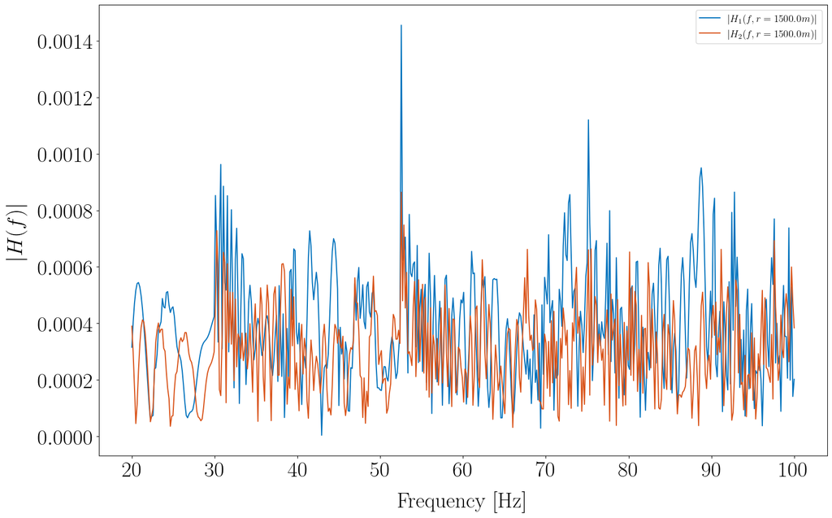

```python
tf1_mod = np.abs(ds.H1)
tf2_mod = np.abs(ds.H2)
plt.figure()
tf1_mod.sel(r=ds.r_ref, method="nearest").plot(label=fr"$\lvert H_1 (f, r={{{ds.r_ref}}}m) \rvert$", color=color(0))
tf2_mod.sel(r=ds.r_ref, method="nearest").plot(label=fr"$\lvert H_2 (f, r={{{ds.r_ref}}}m) \rvert$", color=color(1))
plt.ylabel(r"$\lvert H(f) \rvert$")
plt.legend()
plt.title("")
```

### Rapport des fonctions de transfert

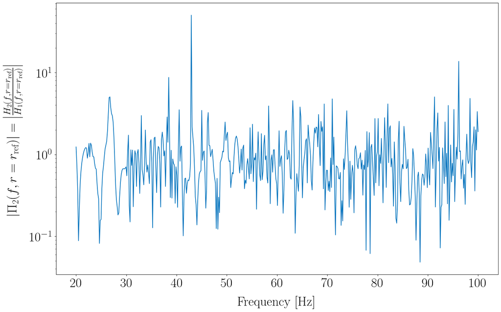

```python
rtf2_mod = ds.module.sel(h_index=2)
rtf2_mod_log = 10 * np.log10(rtf2_mod)
plt.figure()
rtf2_mod.sel(r=ds.r_ref, method="nearest").plot(
    label=rf"$\lvert \Pi_{2} (f, r={{{ds.r_ref}}}m) \rvert$", color=color(0)
)
# rtf2_mod_log.sel(r=ds.r_ref, method="nearest").plot(
#     label=rf"$\lvert \Pi_{2} (f, r={{{ds.r_ref}}}m) \rvert$", color=color(0)
# )
plt.ylabel(
    r"$\lvert \Pi_2(f, r=r_\text{ref}) \rvert = \left \lvert \frac{H_2(f, r=r_\text{ref})}{H_1(f, r=r_\text{ref})}  \right \rvert$"
)
plt.yscale("log")
plt.title("")
# plt.legend(fontsize=16)
```

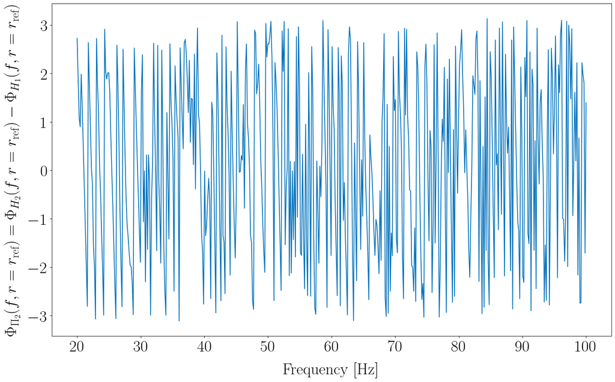

```python
rtf2_phase = ds.phase.sel(h_index=2)
plt.figure()
rtf2_phase.sel(r=ds.r_ref, method="nearest").plot(color=color(0))

plt.ylabel(
    r"$ \Phi_{\Pi_2}(f, r=r_\text{ref})  = \Phi_{H_2}(f, r=r_\text{ref}) - \Phi_{H_1}(f, r=r_\text{ref})$"
)
plt.title("")
```

### Pertes dans le guide d'onde

```python
I_1 = np.abs(4 * np.pi * ds.H1) ** 2
I_2 = np.abs(4 * np.pi * ds.H2) ** 2
I_1_dB = -10 * np.log10(I_1 + 1e-12)
I_2_dB = -10 * np.log10(I_2 + 1e-12)
```

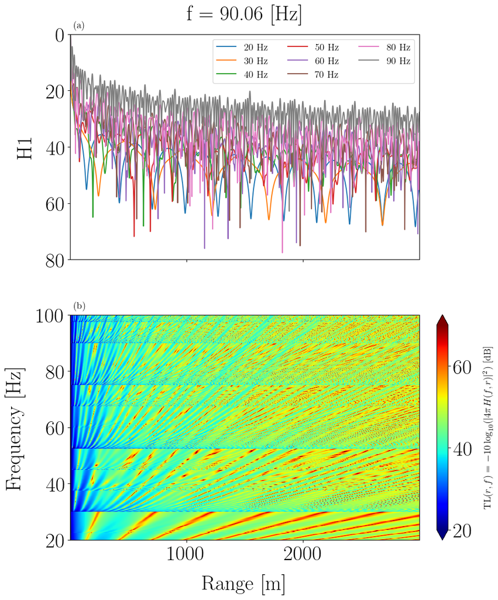

```python
plot_intensity(I_1_dB, fmin, fmax, step_f=10)
```

### Lien avec le rapport des fonctions de transfert

Les pertes par transmissions associées à chacun des capteurs s'écrivent : $$ \text{TL}_1(r, f) = -10 \log_{10}(\lvert 4 \pi H_1(f, r) \rvert^2) $$ et $$ \text{TL}_2(r, f) = -10 \log_{10}(\lvert 4 \pi H_2(f, r) \rvert^2) $$

Le module du rapport des fonctions de transfert s'écrit donc en fonction des pertes $\text{TL}_1(r, f)$ et $\text{TL}_2(r, f)$ :

$$ 10 \log_{10} \left( \lvert \Pi_2(f, r) \rvert^2 \right) = 10 \log_{10}(\left \lvert \frac{4 \pi H_2(f, r)}{4 \pi H_1(f, r)} \right \rvert^2) \newline = \text{TL}_1(r, f) - \text{TL}_2(r, f) $$

```
(<Figure size 1600x1200 with 6 Axes>,
 array([<Axes: title={'center': '$\\text{TL}_1(r, f) = -10 \\log_{10}(\\lvert 4 \\pi H_1(f, r) \\rvert^2)$'}>,
        <Axes: title={'center': '$\\text{TL}_2(r, f) = -10 \\log_{10}(\\lvert 4 \\pi H_2(f, r) \\rvert^2)$'}>,
        <Axes: title={'center': '$10 \\log_{10} \\left( \\lvert \\Pi_2(f, r) \\rvert^2 \\right) =  \\text{TL}_1(r, f) - \\text{TL}_2(r, f) $'}>],
       dtype=object))
```

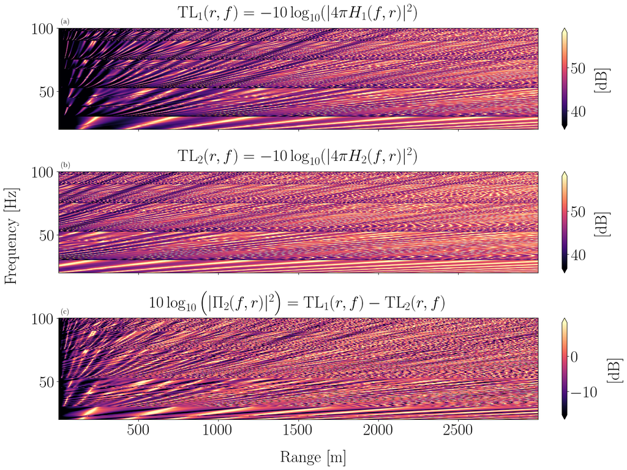

```python
plot_tl_pi_frequency_range_plan(I_1_dB, I_2_dB, rtf2_mod, x_coord="r", y_coord="f")
```

On peut également visualiser dans le plan (f, r) comme précédemment (par exemple pour les essais Groix)

```
(<Figure size 1600x1200 with 6 Axes>,
 array([<Axes: title={'center': '$\\text{TL}_1(r, f) = -10 \\log_{10}(\\lvert 4 \\pi H_1(f, r) \\rvert^2)$'}>,
        <Axes: title={'center': '$\\text{TL}_2(r, f) = -10 \\log_{10}(\\lvert 4 \\pi H_2(f, r) \\rvert^2)$'}>,
        <Axes: title={'center': '$10 \\log_{10} \\left( \\lvert \\Pi_2(f, r) \\rvert^2 \\right) =  \\text{TL}_1(r, f) - \\text{TL}_2(r, f) $'}>],
       dtype=object))
```

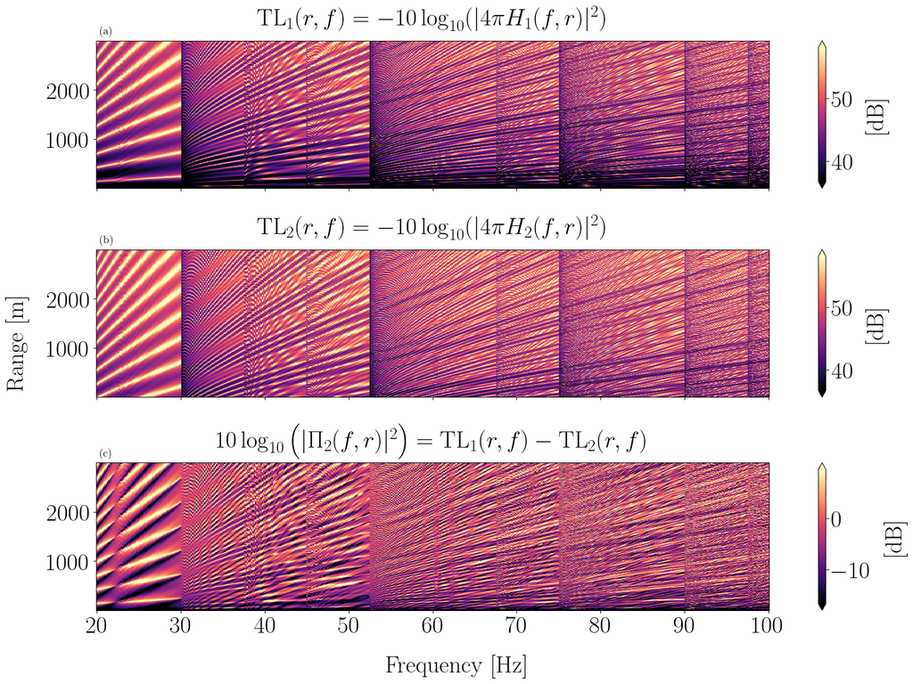

```python
plot_tl_pi_frequency_range_plan(I_1_dB, I_2_dB, rtf2_mod, x_coord="f", y_coord="r")
```

# Filtrage dans le plan (f, k)

L'objectif est d'extraire l'information associée aux interférences modales de grandes longueurs d'ondes (i.e à des petits $\Delta_{k{mn}}$) afin d'obtenir un lobe principal plus large permettant la mise en œuvre, en pratique de la méthode.

Pour se faire on applique une transformée de Fourier le long de l'axe r et on applique un filtre passe bas dans le domaine des nombres d'ondes. La distance $\theta$ est ensuite calculée sur les signaux filtrés.

## Filtrage sur l'ensemble des positions

Afin d'illustrer on commence par appliquer la transformée de Fourier en espace sur l'ensemble des échantillons.

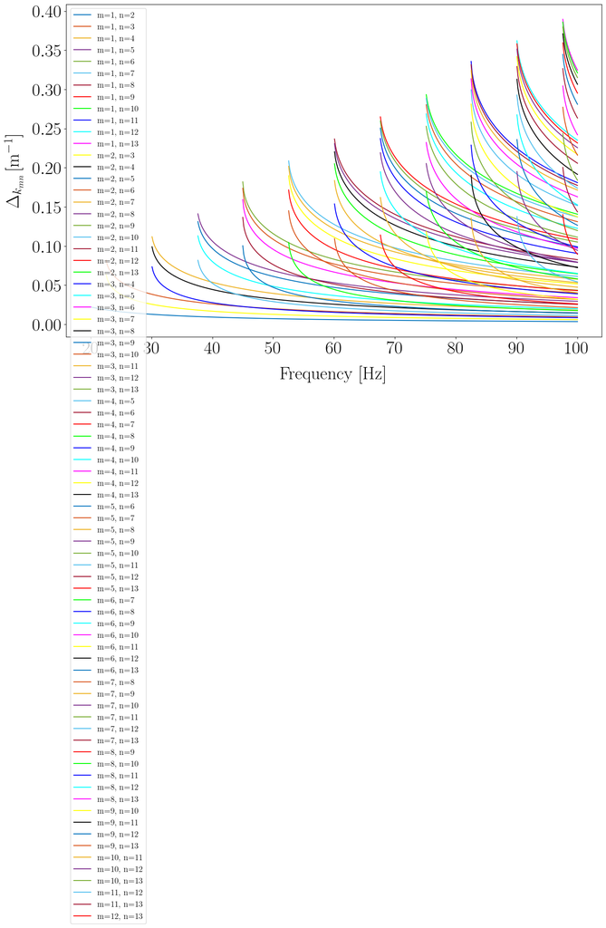

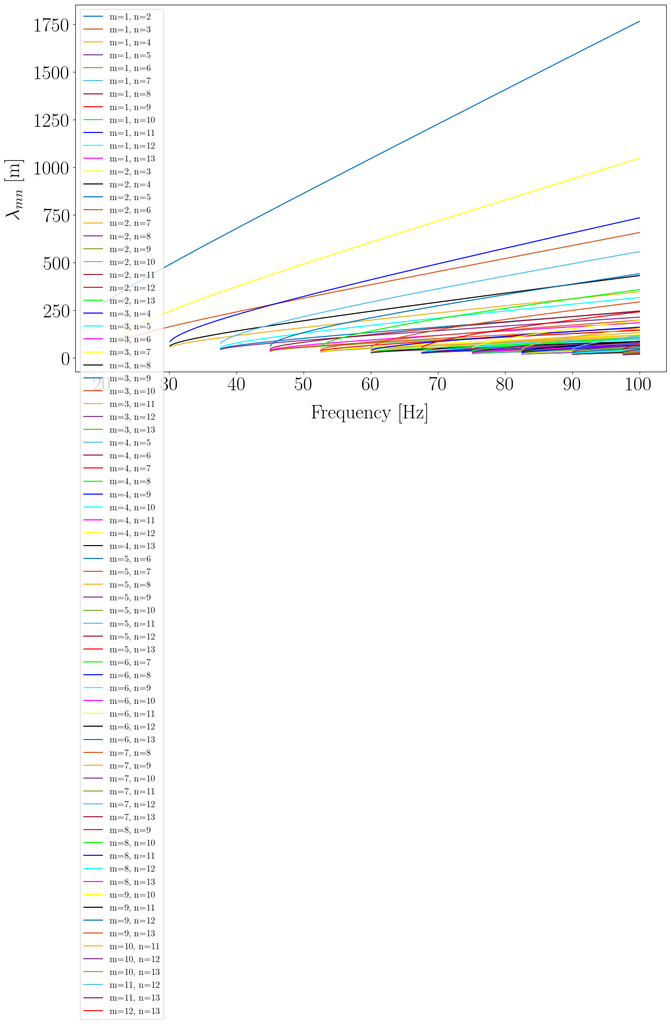

```python
from propa.ideal_waveguide import kr, kz
n_max = M
modes = np.arange(1, n_max + 1)
M = len(modes)
f = ds.f.values

plt.figure()
j = 0
for i_m in range(M):
    for i_n in range(i_m + 1, M):
        delta_kmn = kr(modes[i_m], f, waveguide_depth, bottom_bc=bottom_bc) - kr(
            modes[i_n], f, waveguide_depth, bottom_bc=bottom_bc
        )

        plt.plot(f, delta_kmn, label=f"m={modes[i_m]}, n={modes[i_n]}", color=color(j))
        j+=1

plt.legend()
plt.xlabel("Frequency [Hz]")
plt.ylabel(r"$\Delta_{k_{mn}}\, [\text{m}^{-1}]$")

plt.figure()
j = 0
for i_m in range(M):
    for i_n in range(i_m + 1, M):
        delta_kmn = kr(modes[i_m], f, waveguide_depth, bottom_bc=bottom_bc) - kr(
            modes[i_n], f, waveguide_depth, bottom_bc=bottom_bc
        )
        lambda_mn = 2*np.pi / delta_kmn
        plt.plot(f, lambda_mn, label=f"m={modes[i_m]}, n={modes[i_n]}", color=color(j))
        j += 1

plt.legend()
plt.xlabel("Frequency [Hz]")
plt.ylabel(r"$\lambda_{mn}$ [m]")
```

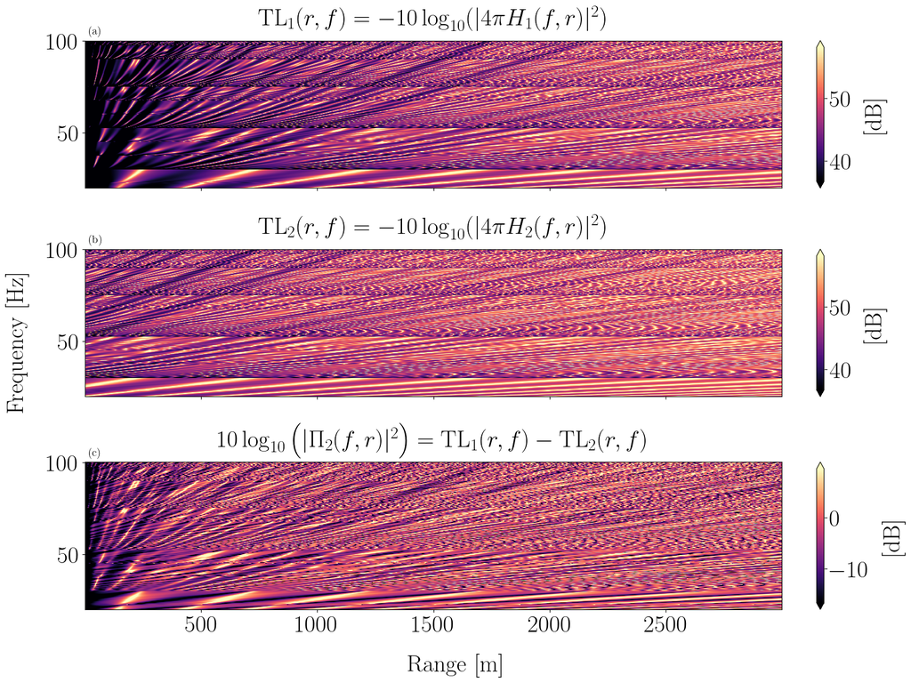

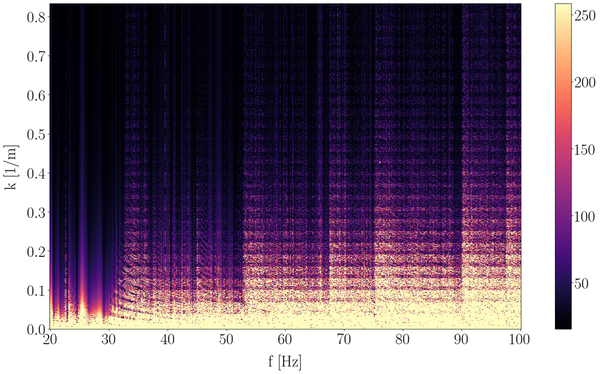

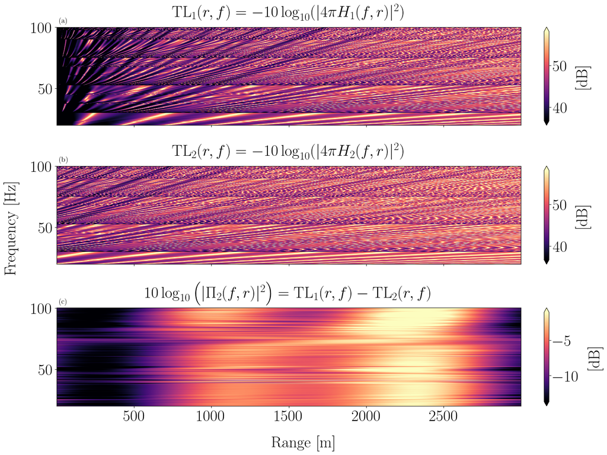

```python
distances = ["hermitian_angle"]


I_1 = np.abs(4 * np.pi * ds.H1) ** 2
I_2 = np.abs(4 * np.pi * ds.H2) ** 2
I_1_dB = -10 * np.log10(I_1 + 1e-12)
I_2_dB = -10 * np.log10(I_2 + 1e-12)

rtf2_mod = ds.module.sel(h_index=2)

fig, axs = plot_tl_pi_frequency_range_plan(
    I_1_dB, I_2_dB, rtf2_mod, x_coord="r", y_coord="f"
)
# fig.suptitle(f"M = {n_max}")

# Apply filter
rtf2_mod = 10 * np.log10(rtf2_mod**2)
# Apply FFT along the r dimension
dr = ds.r.values[1] - ds.r.values[0]
rtf2_mod_fft = np.fft.rfft(rtf2_mod, axis=1)
k = np.fft.rfftfreq(I_1_dB.shape[1], d=dr)  #

plt.figure()
# I_1_dB_fft_show = np.abs(I_1_dB_fft)
# I_1_dB_fft_show = I_1_dB_fft_show[:, k < 0.175]
# k_show = k[k < 0.175]
vmin = np.percentile(np.abs(rtf2_mod_fft), 10)
vmax = np.percentile(np.abs(rtf2_mod_fft), 90)
plt.pcolormesh(ds.f.values, k, np.abs(rtf2_mod_fft).T, cmap="magma", vmax=vmax, vmin=vmin)
plt.colorbar()
plt.xlabel("f [Hz]")
plt.ylabel("k [1/m]")

# Filter desired k
rtf2_mod_fft_filt = np.copy(rtf2_mod_fft)
k_max = 0.001
rtf2_mod_fft_filt[:, k > k_max] = 0
rtf2_mod_filt = np.fft.irfft(rtf2_mod_fft_filt, n=rtf2_mod.shape[1], axis=1)

rtf2_mod_filt_xr = xr.zeros_like(rtf2_mod)
rtf2_mod_filt_xr.data = 10**(rtf2_mod_filt/10)

fig, axs = plot_tl_pi_frequency_range_plan(
    I_1_dB, I_2_dB, rtf2_mod_filt_xr, x_coord="r", y_coord="f"
)
# fig.suptitle(f"M = {n_max}")

plt.show()
```

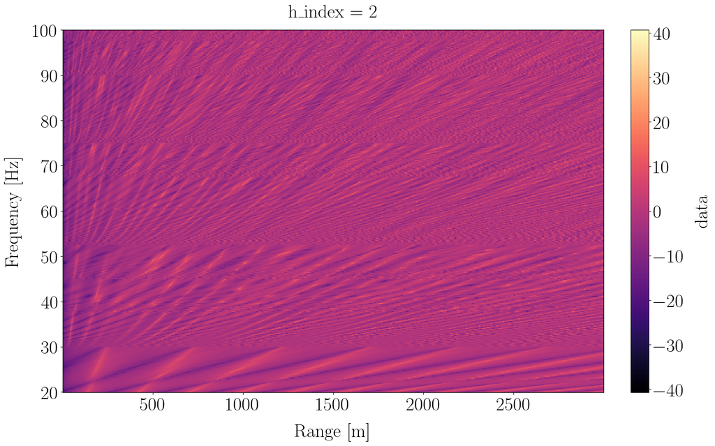

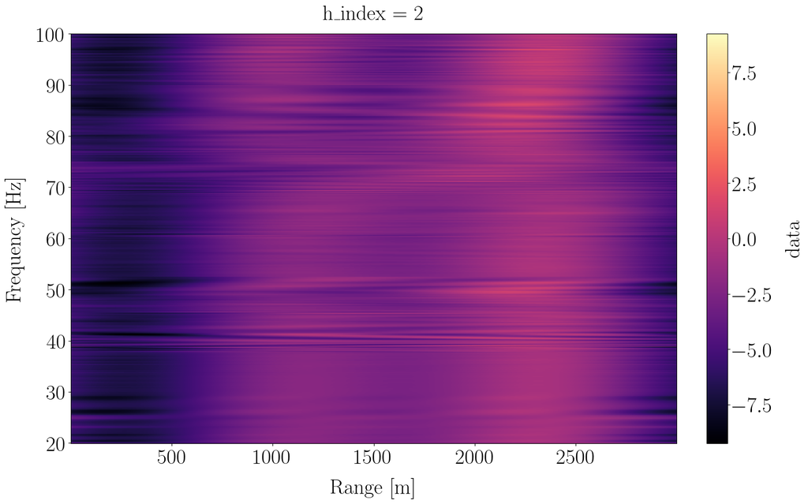

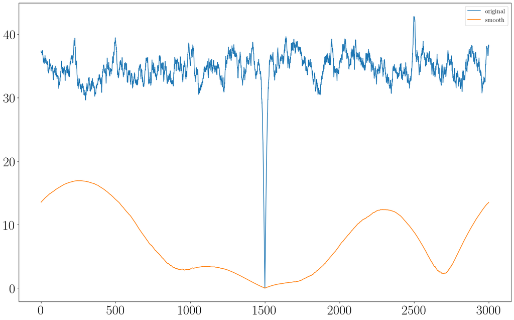

```python
from real_data_analysis.fiberscope_groix.src.localisation.rtf.sensibility.simu.sensi_simu_utils import (
    get_dist,
    plot_distances_vs_range,
)

# Compute theta
dist1 = get_dist(ds, distances=distances)

# Plot theta vs range
r_grid_km = ds.r.values * 1e-3
# plot_distances_vs_range(r_grid_km, dist, root_fig="")

# Compute theta
ds_smooth = ds.copy()

rep = np.ones_like(ds_smooth.data)
rep[1, ...] = rtf2_mod_filt_xr.values
ds_smooth.data.data = rep
idx_r_ref = np.argmin(np.abs(ds.r.values - ds.r_ref))
ds_smooth.data_ref.data = rep[:, :, idx_r_ref]
plt.figure()
a = 10 * np.log10(np.abs(ds.data.sel(h_index=2)))
a.plot(x="r", cmap="magma")

plt.figure()
a = 10 * np.log10(np.abs(ds_smooth.data.sel(h_index=2)))
a.plot(x="r", cmap="magma")

plt.show()
dist2 = get_dist(ds_smooth, distances=distances)


plt.figure()
plt.plot(ds.r.values, dist1["hermitian_angle"]["d"], label="original")
plt.plot(ds.r.values, dist2["hermitian_angle"]["d"], label="smooth")
plt.legend()
plt.show()

# # Plot theta vs range
# r_grid_km = ds.r.values * 1e-3
# plot_distances_vs_range(r_grid_km, dist, root_fig="")
```

Plus le nombre d'onde de coupure $k_c$ est petit plus le lobe principal est large. Cet élargissement se fait au détriment du contraste.

En pratique, les sources ne suivent pas nécessairement une trajectoire rectiligne alignée sur un couple de capteur. De plus, on souhaite conserver un contraste suffisant. Une approche intermédiaire consiste donc à appliquer la démarche précédente sur des fenêtres glissantes.

## Filtrage glissant

Dans la suite :

- La séquence entière est découpée en $Q$ fenêtres notées $\left ( I_q \right )_{q \in [0, Q-1]}$.
- Chaque fenêtre $I_q$ contient les estimations de $2P + 1$ vecteurs de RTF (correspondant ici à $2P + 1$ positions $r_p$ successives).
- Le recouvrement entre les fenêtres $I_q$ est de $2P$ positions $r_p$ de sorte que la fenêtre glisse d'une unique position lorsque q augmente de 1.

```python
# Range step
dr = ds.r.values[1] - ds.r.values[0]
n_r = ds.r.size

# Define the size of the Iq windows
P = 100
n_overlap_I = 1
n_I = 2 * P + 1
size_I_r = n_I * dr

print(
    f"Selected window I size:  n_I = {n_I} samples (equivalent to L_I = {size_I_r:.1f}m)"
)

# Compute the number of I_q windows Q
Q = int(np.floor((n_r + n_overlap_I - n_I)/n_overlap_I))
print(f"Number of available segments I : Q = {Q}")
```

```
Selected window I size:  n_I = 201 samples (equivalent to L_I = 120.5m)
Number of available segments I : Q = 4801
```

### Choix du seuil de coupure $k_c$

#### Seuil défini en fonction de la longueur d'onde minimale

On définit le seuil $k_c$ en fonction de la longueur minimale que l'on souhaite conserver.

- Plus $k_c$ est petit, plus les longueurs d'onde conservées sont grandes et donc plus le lobe principal est large.
- Plus $k_c$ est grand, plus l'on préserve des motifs petite échelle et plus le lobe est étroit.

La taille du lobe principale est également déterminé par la largeur de la fenêtre.

ATTENTION : cette définition suppose que l'on connaisse l'échantillonnage spatial des positions (i.e $\Delta_r$) pour le calcul du vecteur de nombre d'onde k. En pratique, cette information est inconnue et le vecteur de k est arbitraire (i.e calculé avec d=1 dans le paramètre de la fonction rfftfreq).µ

```python
# k_max = 0.005

k_win = 2 * np.pi / size_I_r    # k for lambda = L_I
k_max = k_win / 5       # Lambda min = 8 * L_I
print(f"k_c = {k_max}")
lambda_c = 2 * np.pi / k_max
print(f"Lambda min = {lambda_c:.2f}m")

print(f"delta_k resolution = {1 / size_I_r:.5f} m^-1")
```

```
k_c = 0.010426827349542455
Lambda min = 602.60m
delta_k resolution = 0.00830 m^-1
```

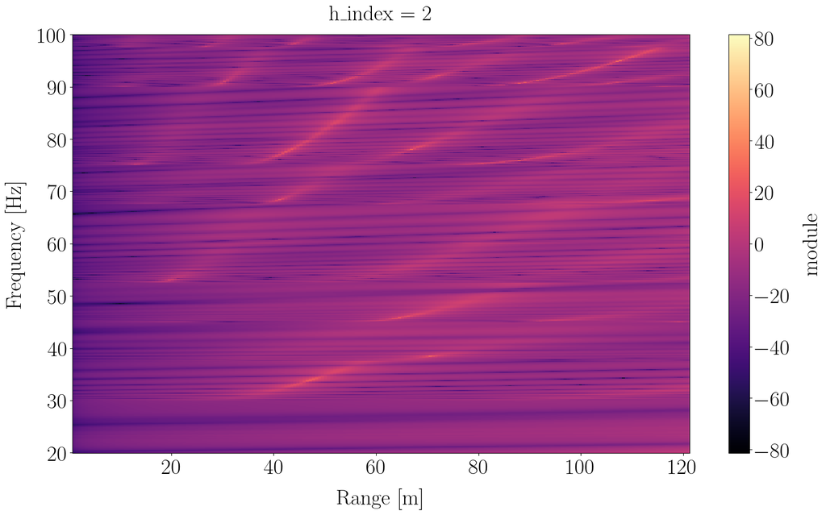

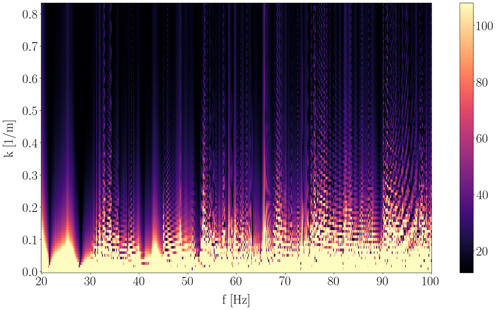

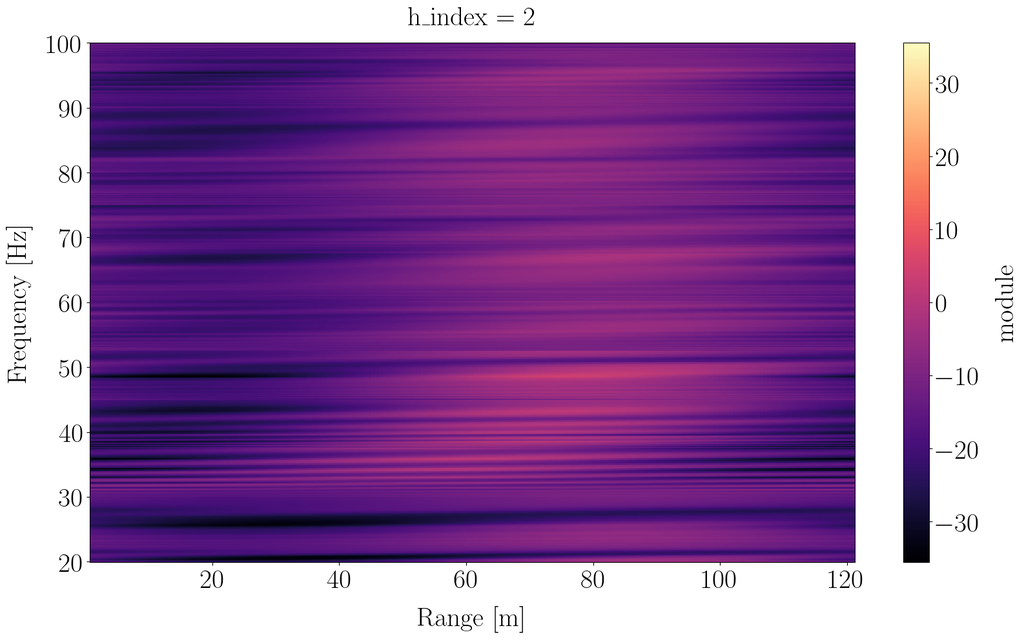

```python
# k_max = 0.005
# lambda_c = 2*np.pi/k_max
# print(f"Lambda min = {lambda_c}")

rtf_mod = ds.module.sel(h_index=2)

smooth_data = np.ones_like(ds.data)
rtf_mod_smooth = rtf_mod.copy().values

for q in range(0, Q):
    I_q_inf = q * n_overlap_I
    I_q_sup = q * n_overlap_I + n_I
    I_q_center = q * n_overlap_I + P # P = n_I // 2
    # print(I_q_inf, I_q_sup)
    # Select I_q
    rtf_I_q = rtf_mod.isel(r=slice(I_q_inf, I_q_sup))
    # Apply filter
    rtf_I_q = 10 * np.log10(rtf_I_q**2)
    # Apply FFT along the r dimension
    rtf_I_q_fft = np.fft.rfft(rtf_I_q, axis=1)
    k = np.fft.rfftfreq(rtf_I_q.shape[1], d=dr)  #

    # Filter desired k
    rtf_I_q_fft_filt = np.copy(rtf_I_q_fft)
    rtf_I_q_fft_filt[:, k > k_max] = 0
    rtf_I_q_filt = np.fft.irfft(rtf_I_q_fft_filt, n=rtf_I_q.shape[1], axis=1)
    rtf_I_q_filt = 10 ** (rtf_I_q_filt / 20)

    if q == 0:
        plt.figure()
        rtf_I_q.plot(x="r", cmap="magma")

        plt.figure()
        vmin = np.percentile(np.abs(rtf_I_q_fft), 10)
        vmax = np.percentile(np.abs(rtf_I_q_fft), 90)
        plt.pcolormesh(
            ds.f.values, k, np.abs(rtf_I_q_fft).T, cmap="magma", vmax=vmax, vmin=vmin
        )
        plt.colorbar()
        plt.xlabel("f [Hz]")
        plt.ylabel("k [1/m]")

        plt.figure()
        rtf_I_q_filt_xr = xr.zeros_like(rtf_I_q)
        rtf_I_q_filt_xr.data = rtf_I_q_filt
        rtf_I_q_filt_plot = 10 * np.log10(rtf_I_q_filt_xr**2)
        rtf_I_q_filt_plot.plot(x="r", cmap="magma")

    # Store modified rtf
    rtf_mod_smooth[:, I_q_center] = rtf_I_q_filt[:, P]
    # rtf_I_q_filt_P = rtf_I_q_filt[:, P]     # Center of the box
    # smooth_rtfs.append(rtf_I_q_filt_P)

# smooth_rtfs = np.array(smooth_rtfs)
# print(smooth_rtfs.shape)
```

```python
ds_smooth = ds.copy()

rep = np.ones_like(ds.data)
rep[1, ...] = rtf_mod_smooth
ds_smooth.data.data = rep
idx_r_ref = np.argmin(np.abs(ds.r.values - ds.r_ref))
ds_smooth.data_ref.data = rep[:, :, idx_r_ref]
```

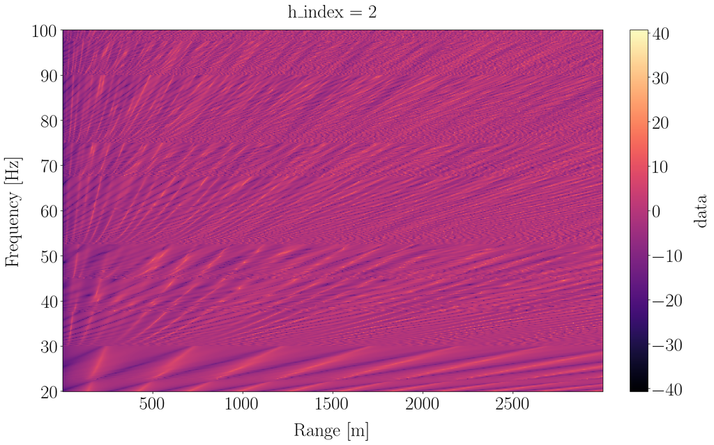

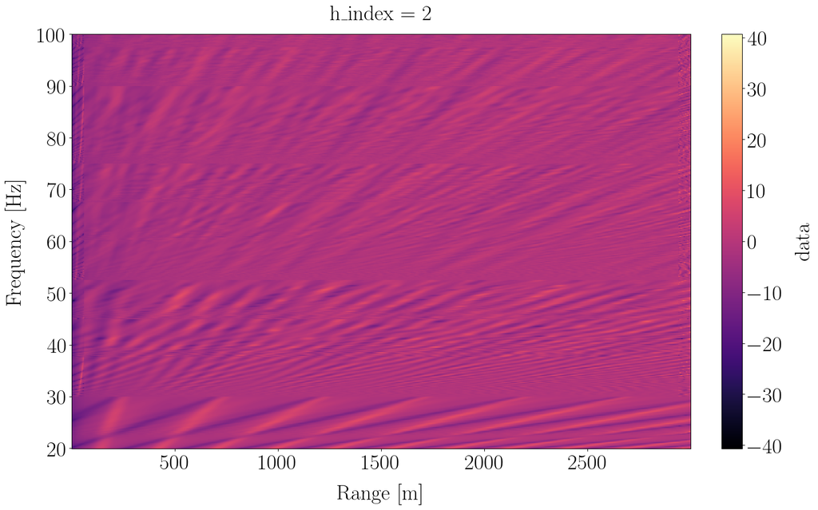

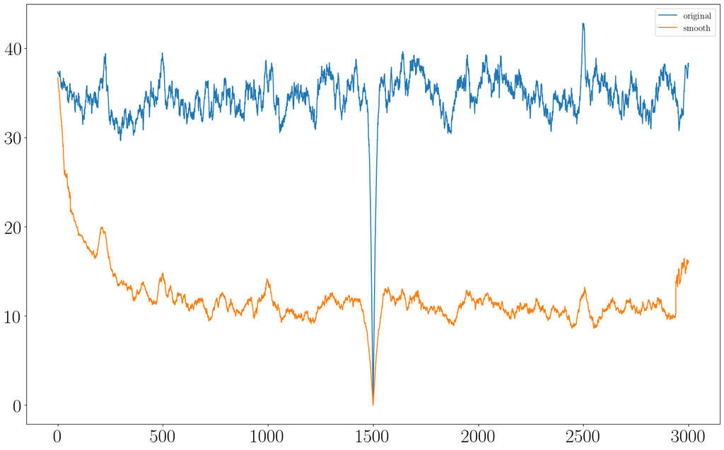

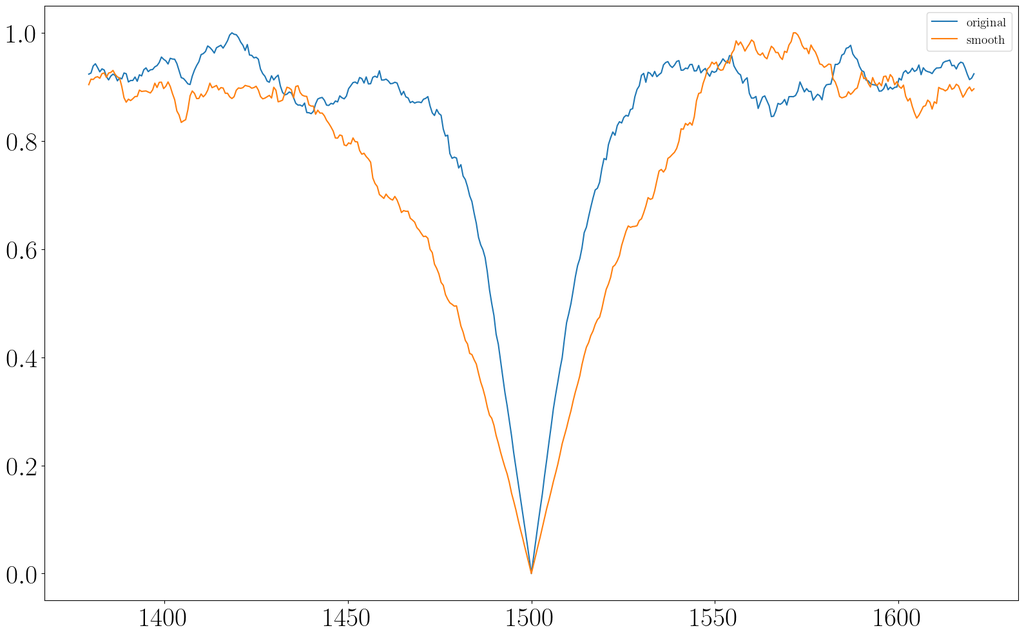

```python
plt.figure()
a = 10 * np.log10(np.abs(ds.data.sel(h_index=2)))
a.plot(x="r", cmap="magma")

plt.figure()
a = 10 * np.log10(np.abs(ds_smooth.data.sel(h_index=2)))
a.plot(x="r", cmap="magma")

dist1 = get_dist(ds, distances=distances)
dist2 = get_dist(ds_smooth, distances=distances)

plt.figure()
plt.plot(ds.r.values, dist1["hermitian_angle"]["d"], label="original")
plt.plot(ds.r.values, dist2["hermitian_angle"]["d"], label="smooth")
plt.legend()

# d1 = (dist1["hermitian_angle"]["d"] - dist1["hermitian_angle"]["d"].min()) /  (dist1["hermitian_angle"]["d"].max() - dist1["hermitian_angle"]["d"].min())
# d2 = (dist2["hermitian_angle"]["d"] - dist2["hermitian_angle"]["d"].min()) /  (dist2["hermitian_angle"]["d"].max() - dist2["hermitian_angle"]["d"].min())
# plt.figure()
# plt.plot(ds.r.values, d1, label="original")
# plt.plot(ds.r.values, d2, label="smooth")
# plt.legend()

# Zoom on main lobe
r_offset = size_I_r
zoom_inf = np.argmin(np.abs(ds.r.values - (ds.r_ref - r_offset)))
zoom_sup = np.argmin(np.abs(ds.r.values - (ds.r_ref + r_offset)))
d1_zoom = dist1["hermitian_angle"]["d"][zoom_inf : zoom_sup + 1]
d2_zoom = dist2["hermitian_angle"]["d"][zoom_inf : zoom_sup + 1]
r_zoom = ds.r.values[zoom_inf : zoom_sup + 1]
d1_zoom = (d1_zoom - d1_zoom.min()) / (d1_zoom.max() - d1_zoom.min())
d2_zoom = (d2_zoom - d2_zoom.min()) / (d2_zoom.max() - d2_zoom.min())
plt.figure()
plt.plot(r_zoom, d1_zoom, label="original")
plt.plot(r_zoom, d2_zoom, label="smooth")
plt.legend()



# plt.xlim([ds.r_ref - 150, ds.r_ref + 150])
```

C'est un peu mieux, pas miraculeux, mais on peut légèrement élargir le lobe principal au prix du contraste.

Le problème est a priori de bien choisir la taille des fenêtres et le nombre d'onde de coupure $k_c$ du filtre passe bas à appliquer.

#### Seuil défini en fonction du percentile d'énergie dans chaque bande

Dans le cas où la période d'échantillonnage spatial est inconnue on doit définir le seuil $k_c$ automatiquement.

Pour chaque bin fréquentiel, on définit le seuil en fonction d'un percentile $q$ donné de la distribution d'énergie.

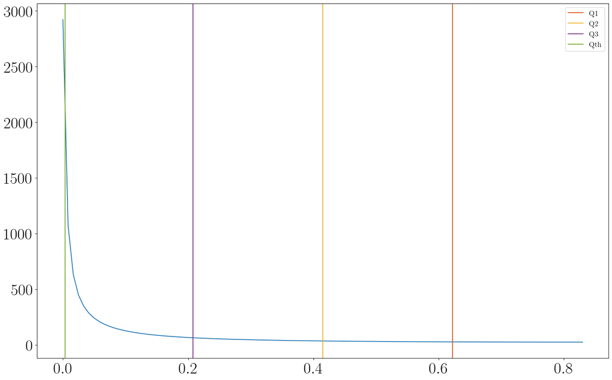

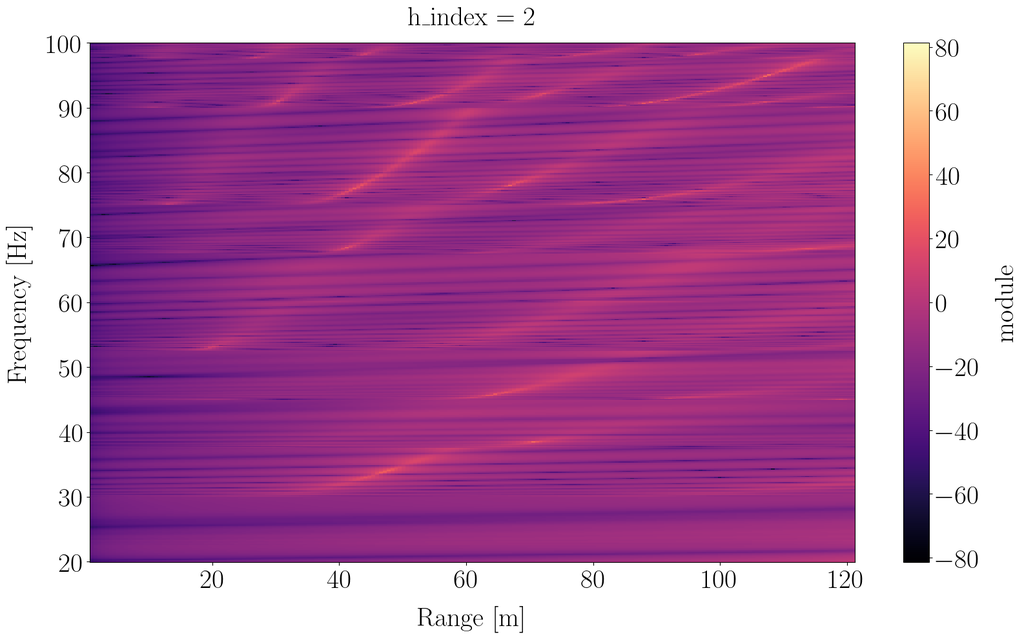

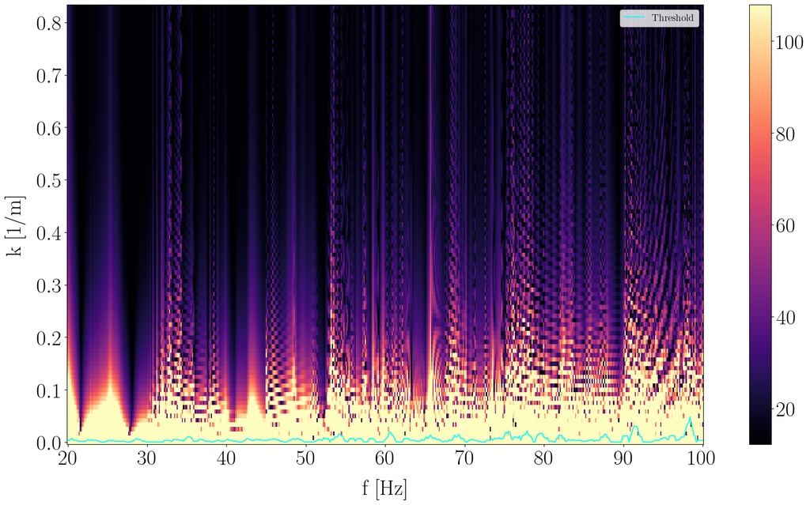

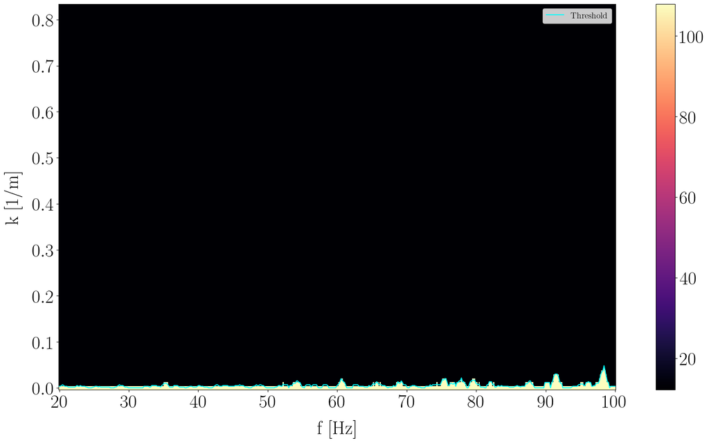

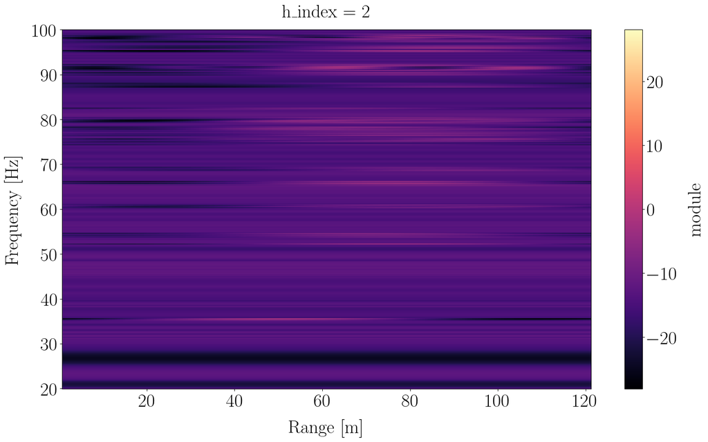

```python
f = ds.f.values
qth = 99.5
# Visualize the energy distribution
rtf_mod = ds.module.sel(h_index=2)

smooth_data = np.ones_like(ds.data)
rtf_mod_smooth = rtf_mod.copy().values

for q in range(0, Q):
    I_q_inf = q * n_overlap_I
    I_q_sup = q * n_overlap_I + n_I
    I_q_center = q * n_overlap_I + P  # P = n_I // 2
    # print(I_q_inf, I_q_sup)
    # Select I_q
    rtf_I_q = rtf_mod.isel(r=slice(I_q_inf, I_q_sup))
    # Apply filter
    rtf_I_q = 10 * np.log10(rtf_I_q**2)
    # Apply FFT along the r dimension
    rtf_I_q_fft = np.fft.rfft(rtf_I_q, axis=1)
    rtf_I_q_psd = np.abs(rtf_I_q_fft)

    k = np.fft.rfftfreq(rtf_I_q.shape[1], d=dr)  #

    # Extract quantiles of the distribution and their corresponding x values
    q_th = np.percentile(rtf_I_q_psd, qth, axis=1)

    # # Get abcisse corresponding to the quantiles : x_q1, mu(x_q1) = q1, x_q2, mu(x_q2) = q2, x_q3, mu(x_q3) = q3
    dx_qth = np.abs(rtf_I_q_psd - q_th[:, np.newaxis])  #
    idx_xqth = np.argmin(dx_qth, axis=1)
    x_qth = k[idx_xqth]
    # print(x_qth)

    # Smooth with rolling average to avoid abrupt changes betweens adjacent bins
    n_roll_avg = 5
    x_qth = np.convolve(x_qth, np.ones(n_roll_avg) / n_roll_avg, mode="same")

    # Filter desired k
    rtf_I_q_fft_filt = np.copy(rtf_I_q_fft)     # nf, nk
    # Define dedicated mask
    kk, ff = np.meshgrid(k, f)
    mask_fk = kk > x_qth[:, np.newaxis]
    # Apply mask
    rtf_I_q_fft_filt[mask_fk] = 0
    rtf_I_q_filt = np.fft.irfft(rtf_I_q_fft_filt, n=rtf_I_q.shape[1], axis=1)
    rtf_I_q_filt = 10 ** (rtf_I_q_filt / 20)

    if q == 0:
        q1 = np.percentile(rtf_I_q_psd, 25, axis=1)
        q2 = np.percentile(rtf_I_q_psd, 50, axis=1)
        q3 = np.percentile(rtf_I_q_psd, 75, axis=1)

        # Q1
        dx_q1 = np.abs(rtf_I_q_psd - q1[:, np.newaxis])  #
        idx_xq1 = np.argmin(dx_q1, axis=1)
        x_q1 = k[idx_xq1]
        # Q2
        dx_q2 = np.abs(rtf_I_q_psd - q2[:, np.newaxis])
        idx_xq2 = np.argmin(dx_q2, axis=1)
        x_q2 = k[idx_xq2]
        # Q3
        dx_q3 = np.abs(rtf_I_q_psd - q3[:, np.newaxis])
        idx_xq3 = np.argmin(dx_q3, axis=1)
        x_q3 = k[idx_xq3]

        plt.figure()
        plt.plot(k, rtf_I_q_psd[0, :])
        plt.axvline(x_q1[0], color=color(1), label="Q1")
        plt.axvline(x_q2[0], color=color(2), label="Q2")
        plt.axvline(x_q3[0], color=color(3), label="Q3")
        plt.axvline(x_qth[0], color=color(4), label="Qth")
        plt.legend()

        plt.figure()
        rtf_I_q.plot(x="r", cmap="magma")

        plt.figure()
        vmin = np.percentile(rtf_I_q_psd, 10)
        vmax = np.percentile(rtf_I_q_psd, 90)
        plt.pcolormesh(f, k, rtf_I_q_psd.T, cmap="magma", vmax=vmax, vmin=vmin)
        plt.plot(f, x_qth, color="cyan", label="Threshold", zorder=10)
        plt.colorbar()
        plt.xlabel("f [Hz]")
        plt.ylabel("k [1/m]")
        plt.legend()

        plt.figure()
        rtf_I_q_fft_filt_psd = np.abs(rtf_I_q_fft_filt)**2
        vmin = np.percentile(rtf_I_q_psd, 10)
        vmax = np.percentile(rtf_I_q_psd, 90)
        plt.pcolormesh(
            f, k, np.abs(rtf_I_q_fft_filt_psd).T, cmap="magma", vmax=vmax, vmin=vmin
        )
        plt.plot(f, x_qth, color="cyan", label="Threshold", zorder=10)
        plt.colorbar()
        plt.xlabel("f [Hz]")
        plt.ylabel("k [1/m]")
        plt.legend()

        plt.figure()
        rtf_I_q_filt_xr = xr.zeros_like(rtf_I_q)
        rtf_I_q_filt_xr.data = rtf_I_q_filt
        rtf_I_q_filt_plot = 10 * np.log10(rtf_I_q_filt_xr**2)
        rtf_I_q_filt_plot.plot(x="r", cmap="magma")

        # print(I_q_center)

    # Store modified rtf
    rtf_mod_smooth[:, I_q_center] = rtf_I_q_filt[:, P]
    # rtf_I_q_filt_P = rtf_I_q_filt[:, P]     # Center of the box
    # smooth_rtfs.append(rtf_I_q_filt_P)

# smooth_rtfs = np.array(smooth_rtfs)
# print(smooth_rtfs.shape)
```

```python
ds_smooth = ds.copy()

rep = np.ones_like(ds.data)
rep[1, ...] = rtf_mod_smooth
ds_smooth.data.data = rep
idx_r_ref = np.argmin(np.abs(ds.r.values - ds.r_ref))
ds_smooth.data_ref.data = rep[:, :, idx_r_ref]
```

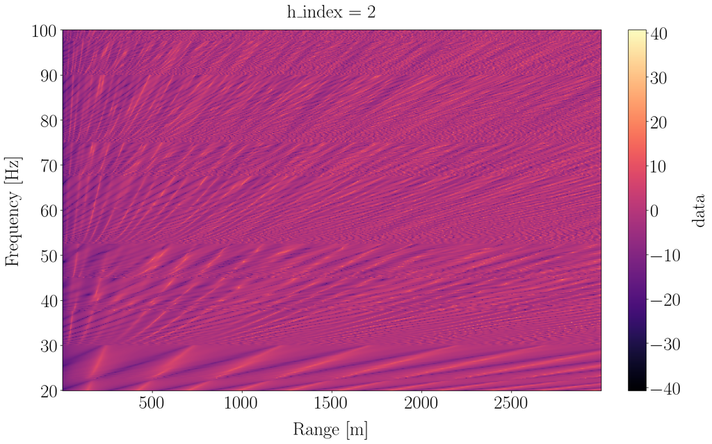

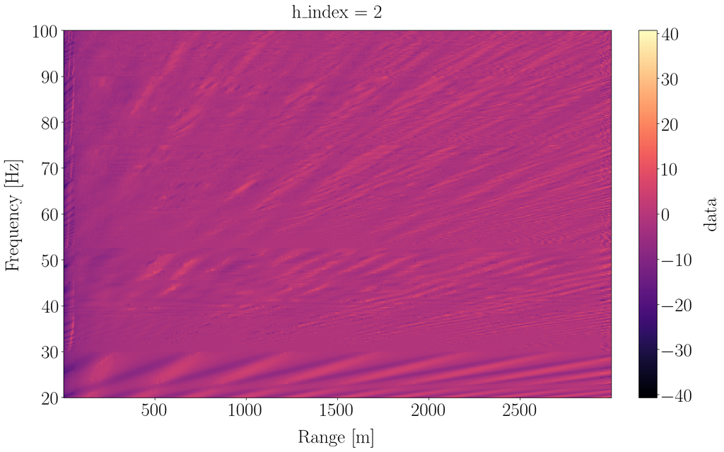

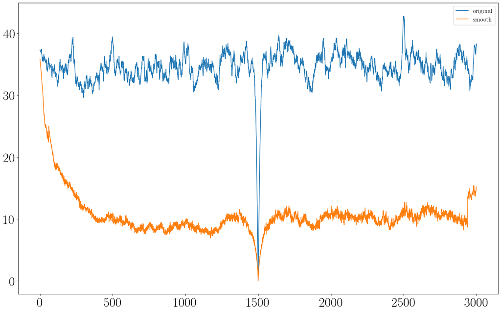

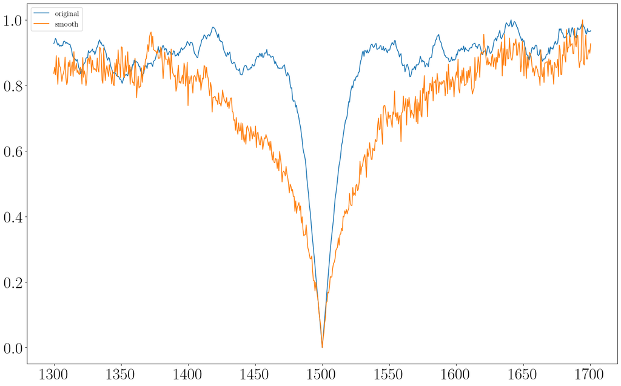

```python
plt.figure()
a = 10 * np.log10(np.abs(ds.data.sel(h_index=2)))
a.plot(x="r", cmap="magma")

plt.figure()
a = 10 * np.log10(np.abs(ds_smooth.data.sel(h_index=2)))
a.plot(x="r", cmap="magma")

dist1 = get_dist(ds, distances=distances)
dist2 = get_dist(ds_smooth, distances=distances)

plt.figure()
plt.plot(ds.r.values, dist1["hermitian_angle"]["d"], label="original")
plt.plot(ds.r.values, dist2["hermitian_angle"]["d"], label="smooth")
plt.legend()

# # Remove first and last points out of windows
# I_q_center_first = 0 * n_overlap_I + P  # P = n_I // 2
# I_q_center_last = (Q-1) * n_overlap_I + P  # P = n_I // 2
# # print(I_q_center_first, I_q_center_last)

# d1 = dist1["hermitian_angle"]["d"][I_q_center_first : I_q_center_last + 1]
# d2 = dist2["hermitian_angle"]["d"][I_q_center_first : I_q_center_last + 1]
# r_valid = ds.r.values[I_q_center_first : I_q_center_last + 1]
# d1 = (d1 - d1.min()) / (d1.max() - d1.min())
# d2 = (d2 - d2.min()) / (d2.max() - d2.min())
# plt.figure()
# plt.plot(r_valid, d1, label="original")
# plt.plot(r_valid, d2, label="smooth")
# plt.legend()


# Zoom on main lobe
r_offset = 200
zoom_inf = np.argmin(np.abs(ds.r.values - (ds.r_ref - r_offset)))
zoom_sup = np.argmin(np.abs(ds.r.values - (ds.r_ref + r_offset)))
d1_zoom = dist1["hermitian_angle"]["d"][zoom_inf : zoom_sup + 1]
d2_zoom = dist2["hermitian_angle"]["d"][zoom_inf : zoom_sup + 1]
r_zoom = ds.r.values[zoom_inf : zoom_sup + 1]
d1_zoom = (d1_zoom - d1_zoom.min()) / (d1_zoom.max() - d1_zoom.min())
d2_zoom = (d2_zoom - d2_zoom.min()) / (d2_zoom.max() - d2_zoom.min())
plt.figure()
plt.plot(r_zoom, d1_zoom, label="original")
plt.plot(r_zoom, d2_zoom, label="smooth")
plt.legend()


# plt.xlim([ds.r_ref - 150, ds.r_ref + 150])

# # debug : Check first is ok
# plt.figure()
# a = 10 * np.log10(np.abs(ds_smooth.data.sel(h_index=2)))
# a.plot(x="r", cmap="magma")
# plt.xlim([ds.r.values[I_q_center_first - 10], ds.r.values[I_q_center_first + 10]])
```